# VIQ - Laboratorio 4 - bis (Redditi 2020)

2022-04-28

### Obiettivi

1. Manipolare data set
2. Grafici essenziali

### Strumento

R ed RStudio, in particolare la libreria tidyverse:

### Dataset

SI utilizza un dataset proveniente dagli [Open-Data del Ministero delle Finanze](https://www1.finanze.gov.it/finanze/analisi_stat/public/index.php?opendata=yes)

In particolare i dati relativi ai redditi ei dati IRPEF relativi alle dichiarazioni dei redditi dell’anno fiscale 2020. Scaricabile da: https://www1.finanze.gov.it/finanze/analisi_stat/public/v_4_0_0/contenuti/Redditi_e_principali_variabili_IRPEF_su_base_comunale_CSV_2020.zip?d=1615465800

## Ritocchi al file

Le colonne (variabili/misure) hanno dei nom che non sono immediatamente utilizzabili in R (non sono degli identificatori), ad esempio `Sigla Provincia` non è utilizzabile con l’operatore di accesso `$`, ma occorre racchiuderlo tra apici inversi: `` "``" ``

```r
redditi$`Sigla Provincia` %>% unique()
```

```
  [1] "PD" "LO" "LC" "SI" "OR" "PE" "MI" "PZ" "RG" "FG" "CN" "MT" "AQ" "RI" "BZ" "SA" NA
 [18] "CT" "FR" "CS" "BS" "PU" "MN" "CR" "VT" "VV" "AP" "TR" "BA" "CL" "CB" "IS" "AL" "BG"
 [35] "RO" "VR" "RM" "RC" "PC" "SS" "EN" "PT" "AT" "TO" "BL" "VA" "MB" "NO" "AG" "VI" "AO"
 [52] "AV" "UD" "CE" "BI" "BN" "IM" "TN" "PV" "VC" "SV" "TE" "SO" "PR" "CO" "CZ" "RE" "TP"
 [69] "ME" "LE" "RA" "PA" "FM" "CH" "TV" "LU" "SP" "AN" "PN" "BT" "AR" "VE" "VB" "BO" "MC"
 [86] "LT" "NU" "SU" "GR" "GE" "FE" "CA" "PG" "SR" "MS" "TA" "PI" "FI" "FC" "MO" "RN" "KR"
[103] "LI" "BR" "PO" "GO" "TS" "0"
```

Inoltre i nomi sono molto lunghi, perciò conviene sostituire in nomi con versioni più brevi, per semplicità ci si limiti alle colonne 4,5,8,23,24

```r
names(redditi)
```

```
 [1] "Anno di imposta"
 [2] "Codice catastale"
 [3] "Codice Istat Comune"
 [4] "Denominazione Comune"
 [5] "Sigla Provincia"
 [6] "Regione"
 [7] "Codice Istat Regione"
 [8] "Numero contribuenti"
 [9] "Reddito da fabbricati - Frequenza"
[10] "Reddito da fabbricati - Ammontare in euro"
[11] "Reddito da lavoro dipendente e assimilati - Frequenza"
[12] "Reddito da lavoro dipendente e assimilati - Ammontare in euro"
[13] "Reddito da pensione - Frequenza"
[14] "Reddito da pensione - Ammontare in euro"
[15] "Reddito da lavoro autonomo (comprensivo dei valori nulli) - Frequenza"
```

[output cut: 36 more lines]

```r
## TODO: sostituire i nomi delle colonne con versioni più brevi

redditi %<>% rename(Comune=4,Provincia=5,contribuenti=8,imponibile_n=23,imponibile_eur=24)

## Soluzione dice:
   # names(redditi)[4] <- "Comune"
   # names(redditi)[5] <- "Provincia"
   # names(redditi)[8] <- "contribuenti"
   # names(redditi)[23] <- "imponibile_n"
   # names(redditi)[24] <- "imponibile_eur"

redditi
```

| Anno di imposta | Codice catastale | Codice Istat Comune | Comune | Provincia | Regione | Codice Istat Regione | contribuenti | Reddito da fabbricati - Frequenza | Reddito da fabbricati - Ammontare in euro | Reddito da lavoro dipendente e assimilati - Frequenza | Reddito da lavoro dipendente e assimilati - Ammontare in euro | Reddito da pensione - Frequenza | Reddito da pensione - Ammontare in euro | Reddito da lavoro autonomo (comprensivo dei valori nulli) - Frequenza | Reddito da lavoro autonomo (comprensivo dei valori nulli) - Ammontare in euro | Reddito di spettanza dell'imprenditore in contabilita' ordinaria (comprensivo dei valori nulli) - Frequenza | Reddito di spettanza dell'imprenditore in contabilita' ordinaria (comprensivo dei valori nulli) - Ammontare in euro | Reddito di spettanza dell'imprenditore in contabilita' semplificata (comprensivo dei valori nulli) - Frequenza | Reddito di spettanza dell'imprenditore in contabilita' semplificata (comprensivo dei valori nulli) - Ammontare in euro | Reddito da partecipazione (comprensivo dei valori nulli) - Frequenza | Reddito da partecipazione (comprensivo dei valori nulli) - Ammontare in euro | imponibile_n | imponibile_eur | Imposta netta - Frequenza | Imposta netta - Ammontare in euro | Bonus spettante - Frequenza | Bonus spettante - Ammontare in euro | Reddito imponibile addizionale - Frequenza | Reddito imponibile addizionale - Ammontare in euro | … |
| --- | --- | --- | --- | --- | --- | --- | --- | --- | --- | --- | --- | --- | --- | --- | --- | --- | --- | --- | --- | --- | --- | --- | --- | --- | --- | --- | --- | --- | --- | --- |
| 2020 | A001 | 028001 | ABANO TERME | PD | Veneto | 05 | 14831 | 7564 | 9593119 | 7747 | 170054564 | 5371 | 112770477 | 247 | 14037809 | 66 | 3836923 | 450 | 8726459 | 999 | 16667508 | 13951 | 324549517 | 11366 | 67923696 | 4319 | 1853780 | 11180 | 307795144 | … |
| 2020 | A004 | 098001 | ABBADIA CERRETO | LO | Lombardia | 03 | 208 | 89 | 78204 | 102 | 1958895 | 82 | 1373800 | 0 | 0 | 0 | 0 | 4 | 68391 | 17 | 77283 | 188 | 3473755 | 155 | 547928 | 68 | 30296 | 153 | 3198548 | … |
| 2020 | A005 | 097001 | ABBADIA LARIANA | LC | Lombardia | 03 | 2451 | 1205 | 1802637 | 1338 | 31937559 | 842 | 17528709 | 29 | 1186371 | NA | NA | 69 | 1536191 | 108 | 2209314 | 2340 | 54880914 | 1938 | 10824433 | 673 | 290106 | 1901 | 52232858 | … |
| 2020 | A006 | 052001 | ABBADIA SAN SALVATORE | SI | Toscana | 09 | 4855 | 2667 | 2731533 | 2393 | 42798957 | 1935 | 31142896 | 34 | 1647320 | 19 | 1126797 | 127 | 1718265 | 341 | 3336911 | 4636 | 81323285 | 3664 | 13319503 | 1508 | 664606 | 3612 | 75498441 | … |
| 2020 | A007 | 095001 | ABBASANTA | OR | Sardegna | 20 | 1728 | 885 | 739857 | 828 | 15680272 | 659 | 11757552 | 11 | 498144 | NA | NA | 76 | 1209601 | 63 | 803066 | 1624 | 29918829 | 1224 | 5171839 | 389 | 165394 | 1193 | 27630485 | … |
| 2020 | A008 | 068001 | ABBATEGGIO | PE | Abruzzo | 13 | 297 | 123 | 66344 | 119 | 1923796 | 140 | 1412893 | 0 | 0 | 0 | 0 | 4 | 55534 | 11 | 121450 | 282 | 3540583 | 168 | 489450 | 72 | 31018 | 166 | 3132585 | … |
| 2020 | A010 | 015002 | ABBIATEGRASSO | MI | Lombardia | 03 | 23199 | 11571 | 14507919 | 13066 | 310721379 | 8200 | 168637394 | 265 | 14437314 | 30 | 2884822 | 480 | 10268648 | 891 | 14417075 | 22202 | 522044991 | 18727 | 105964020 | 6824 | 2934440 | 18407 | 497308382 | … |
| 2020 | A013 | 076001 | ABRIOLA | PZ | Basilicata | 17 | 952 | 307 | 173054 | 434 | 6146862 | 428 | 4991981 | 4 | 253030 | NA | NA | 27 | 264361 | 34 | 129829 | 903 | 11827254 | 596 | 1533953 | 258 | 113845 | 579 | 10145583 | … |
| 2020 | A014 | 088001 | ACATE | RG | Sicilia | 19 | 6815 | 2025 | 1436741 | 4558 | 48230289 | 1514 | 19521012 | 19 | 648243 | 8 | 245631 | 130 | 1473969 | 88 | 630333 | 6545 | 71450139 | 3649 | 7786043 | 2907 | 1225115 | 3543 | 54337992 | … |
| 2020 | A015 | 071001 | ACCADIA | FG | Puglia | 16 | 1667 | 810 | 564029 | 692 | 10582188 | 760 | 9603548 | 15 | 719783 | NA | NA | 55 | 502148 | 33 | 599254 | 1594 | 22180464 | 1060 | 3271611 | 418 | 177348 | 1037 | 19674723 | … |

[output cut: 990 more lines]

```r
NA
```

## Esplorazione

Come sono distribuiti i redditi imponibili (col 24)?

```r
## TODO informazioni sulla distirbuzione (sintesi a 5 numeri e istogramma/profilo di frequenza)

summary(redditi$imponibile_eur)                                     # sintesi a 5 numeri
```

```
     Min.   1st Qu.    Median      Mean   3rd Qu.      Max.
3.895e+05 1.161e+07 2.938e+07 1.031e+08 8.051e+07 4.790e+10
```

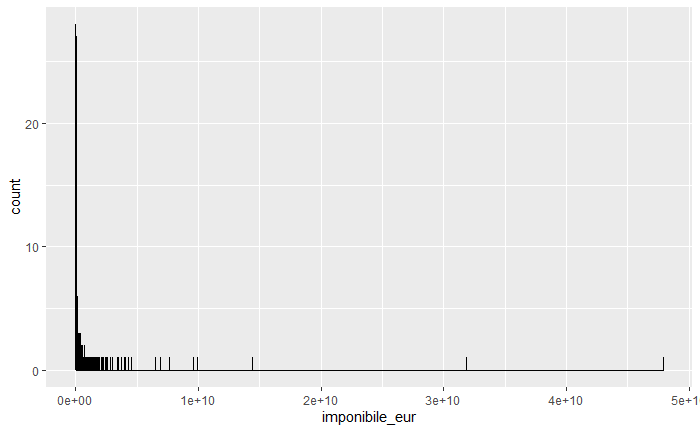

```r
ggplot(redditi,aes(x=imponibile_eur))+geom_freqpoly(binwidth=1e5)   # Gli istogrammi ( geom_histogram()) mostrano i conteggi con barre; i poligoni di frequenza ( geom_freqpoly()) visualizzano i conteggi con linee. I poligoni di frequenza sono più adatti quando si desidera confrontare la distribuzione tra i livelli di una variabile categoriale.
```

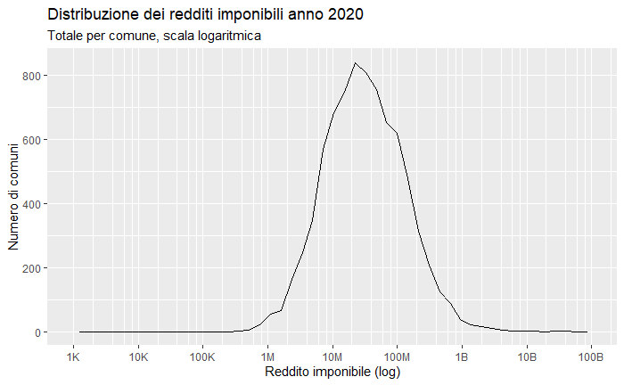

```r
# binwidth=1e6 dovrebbe controllare la larghezza per ogni bin su asse X

# ggplot(redditi %>% filter(`Codice catastale`<"A009"),aes(x=imponibile_eur))+geom_freqpoly()
# ggplot(redditi %>% filter(`Codice catastale`<"A009"),aes(x=imponibile_eur))+
  # geom_freqpoly(binwidth=1e6)

ggplot(redditi,aes(x=imponibile_eur))+
  ylab("Numero di comuni")+
  scale_x_log10(labels=scales::label_number_si(),                               # labels per cambiare le etichette (su asse x mi da roba difficile da leggere, così è comprensibile)
                breaks=10^(3:12),minor_breaks=rep(10^(3:11),each=5)*c(2,4,6,8),
                limits=c(1e3,1e11),name="Reddito imponibile (log)")+
  geom_freqpoly(bins=50)+
  ggtitle("Distribuzione dei redditi imponibili anno 2020","Totale per comune, scala logaritmica")
```

I redditi riportati sono probabilmente il totale di quelli nel comune, possiamo verificare analizzando la correlazione tra il numero di contribuenti e il reddito imponibile.

```r
## TODO: Mostrare graficamente la correlazione tra contribuenti e reddito imponibile

# quello sotto è == cor(redditi$contribuenti, redditi$imponibile_eur))
with(redditi, cor(contribuenti,imponibile_eur))               # with: Valuta un'espressione R in un ambiente costruito dai dati, eventualmente modificando (una copia dei) i dati originali.
```

```
[1] 0.9899651
```

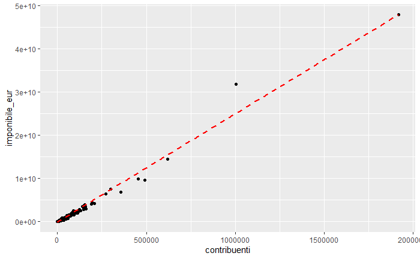

```r
                                                              # cor: correlazione
                                                              # correlazione circa 1 => quasi perfetta
ggplot(redditi,aes(x=contribuenti,y=imponibile_eur))+
  geom_point()+
  geom_smooth(formula=y~x, color="red", linetype=2,se=FALSE)  # Aiuta l'occhio a vedere i modelli in presenza di overplotting.
```

A questo punto è ragionevole che il comune con il maggior reddito sia anche il più grande, trovare il comune col maggior reddito imponibile:

```r
## TODO: trovare il comune col maggior reddito imponibile

redditi %>% filter(imponibile_eur == max(imponibile_eur))
```

| Anno di imposta | Codice catastale | Codice Istat Comune | Comune | Provincia | Regione | Codice Istat Regione | contribuenti | Reddito da fabbricati - Frequenza | Reddito da fabbricati - Ammontare in euro | Reddito da lavoro dipendente e assimilati - Frequenza | Reddito da lavoro dipendente e assimilati - Ammontare in euro | Reddito da pensione - Frequenza | Reddito da pensione - Ammontare in euro | Reddito da lavoro autonomo (comprensivo dei valori nulli) - Frequenza | Reddito da lavoro autonomo (comprensivo dei valori nulli) - Ammontare in euro | Reddito di spettanza dell'imprenditore in contabilita' ordinaria (comprensivo dei valori nulli) - Frequenza | Reddito di spettanza dell'imprenditore in contabilita' ordinaria (comprensivo dei valori nulli) - Ammontare in euro | Reddito di spettanza dell'imprenditore in contabilita' semplificata (comprensivo dei valori nulli) - Frequenza | Reddito di spettanza dell'imprenditore in contabilita' semplificata (comprensivo dei valori nulli) - Ammontare in euro | Reddito da partecipazione (comprensivo dei valori nulli) - Frequenza | Reddito da partecipazione (comprensivo dei valori nulli) - Ammontare in euro | imponibile_n | imponibile_eur | Imposta netta - Frequenza | Imposta netta - Ammontare in euro | Bonus spettante - Frequenza | Bonus spettante - Ammontare in euro | Reddito imponibile addizionale - Frequenza | Reddito imponibile addizionale - Ammontare in euro | … |
| --- | --- | --- | --- | --- | --- | --- | --- | --- | --- | --- | --- | --- | --- | --- | --- | --- | --- | --- | --- | --- | --- | --- | --- | --- | --- | --- | --- | --- | --- | --- |
| 2020 | H501 | 058091 | ROMA | RM | Lazio | 12 | 1918862 | 928513 | 2126057064 | 1062286 | 27121517813 | 623064 | 15203303373 | 40098 | 2410664027 | 2827 | 120130247 | 32283 | 551757809 | 43250 | 1053321833 | 1798777 | 47903317182 | 1417466 | 11385420043 | 460143 | 196879700 | 1374520 | 45653113236 | … |

```r
NA
```

A livello regionale quali sono i comuni con il maggior reddito imponibile?

```r
## TODO: trovare i comuni col maggior reddito imponibile per regione

redditi %>% group_by(Regione) %>% filter(imponibile_eur == max(imponibile_eur))
```

| Anno di imposta | Codice catastale | Codice Istat Comune | Comune | Provincia | Regione | Codice Istat Regione | contribuenti | Reddito da fabbricati - Frequenza | Reddito da fabbricati - Ammontare in euro | Reddito da lavoro dipendente e assimilati - Frequenza | Reddito da lavoro dipendente e assimilati - Ammontare in euro | Reddito da pensione - Frequenza | Reddito da pensione - Ammontare in euro | Reddito da lavoro autonomo (comprensivo dei valori nulli) - Frequenza | Reddito da lavoro autonomo (comprensivo dei valori nulli) - Ammontare in euro | Reddito di spettanza dell'imprenditore in contabilita' ordinaria (comprensivo dei valori nulli) - Frequenza | Reddito di spettanza dell'imprenditore in contabilita' ordinaria (comprensivo dei valori nulli) - Ammontare in euro | Reddito di spettanza dell'imprenditore in contabilita' semplificata (comprensivo dei valori nulli) - Frequenza | Reddito di spettanza dell'imprenditore in contabilita' semplificata (comprensivo dei valori nulli) - Ammontare in euro | Reddito da partecipazione (comprensivo dei valori nulli) - Frequenza | Reddito da partecipazione (comprensivo dei valori nulli) - Ammontare in euro | imponibile_n | imponibile_eur | Imposta netta - Frequenza | Imposta netta - Ammontare in euro | Bonus spettante - Frequenza | Bonus spettante - Ammontare in euro | Reddito imponibile addizionale - Frequenza | Reddito imponibile addizionale - Ammontare in euro | … |
| --- | --- | --- | --- | --- | --- | --- | --- | --- | --- | --- | --- | --- | --- | --- | --- | --- | --- | --- | --- | --- | --- | --- | --- | --- | --- | --- | --- | --- | --- | --- |
| 2020 | A271 | 042002 | ANCONA | AN | Marche | 11 | 73801 | 36885 | 48385059 | 40602 | 843960634 | 27131 | 608658314 | 1329 | 70623333 | 195 | 8082158 | 1625 | 31834001 | 2714 | 49277491 | 70518 | 1617691863 | 56507 | 326928185 | 21262 | 9123750 | 55524 | 1524035328 | … |
| 2020 | A326 | 007003 | AOSTA | AO | Valle d'Aosta | 02 | 25956 | 11954 | 22476778 | 13886 | 287449269 | 10290 | 210839760 | 431 | 21737862 | 54 | 2569403 | 569 | 9995806 | 1389 | 21139707 | 24892 | 562082502 | 20485 | 111025949 | 6760 | 2836628 | 20155 | 534211387 | … |
| 2020 | A662 | 072006 | BARI | BA | Puglia | 16 | 208875 | 99749 | 190430242 | 108820 | 2200817114 | 72726 | 1571662655 | 4015 | 213647461 | 513 | 22558303 | 4982 | 95739782 | 5205 | 103453779 | 195418 | 4293924339 | 148544 | 876934428 | 52159 | 22504160 | 144242 | 4003473619 | … |
| 2020 | A944 | 037006 | BOLOGNA | BO | Emilia Romagna | 08 | 300220 | 141083 | 301984814 | 167995 | 4156996697 | 101614 | 2414803616 | 7206 | 452294012 | 439 | 29748185 | 5725 | 136752056 | 11157 | 273267908 | 285299 | 7605617462 | 236101 | 1690252436 | 80597 | 34425620 | 231327 | 7256018411 | … |
| 2020 | A952 | 021008 | BOLZANO .BOZEN. | BZ | Trentino Alto Adige(P.A.Bolzano) | 04 | 82936 | 16357 | 47594871 | 49603 | 1208234504 | 28563 | 624355795 | 1279 | 91096077 | 210 | 9407391 | 1520 | 33104921 | 3482 | 105087248 | 80088 | 2089905070 | 65636 | 460735988 | 21176 | 8824249 | 64477 | 1994077343 | … |
| 2020 | B354 | 092009 | CAGLIARI | CA | Sardegna | 20 | 104074 | 51292 | 97809321 | 51589 | 1198302611 | 39371 | 957809170 | 2883 | 142832305 | 350 | 12496288 | 2066 | 38308684 | 3721 | 63942238 | 97979 | 2463752628 | 79152 | 557146330 | 22403 | 9521819 | 76962 | 2349328109 | … |
| 2020 | B519 | 070006 | CAMPOBASSO | CB | Molise | 14 | 33106 | 17226 | 21198190 | 16526 | 334648771 | 12462 | 255001868 | 656 | 26825304 | 123 | 4191232 | 823 | 11688184 | 1135 | 15859287 | 31151 | 653418637 | 24006 | 129397383 | 7885 | 3392489 | 23393 | 614067138 | … |
| 2020 | D612 | 048017 | FIRENZE | FI | Toscana | 09 | 273667 | 128161 | 317326380 | 145163 | 3357840368 | 95236 | 2200126174 | 6087 | 338793751 | 449 | 26554695 | 6498 | 132327313 | 11938 | 228812568 | 256763 | 6476619796 | 207839 | 1431294818 | 70845 | 30351529 | 202985 | 6145173995 | … |
| 2020 | D969 | 010025 | GENOVA | GE | Liguria | 07 | 454026 | 224740 | 354686790 | 246034 | 5240706546 | 166200 | 3634379643 | 5908 | 340677977 | 548 | 35042762 | 8558 | 187285120 | 16571 | 341300571 | 432680 | 9891798883 | 354264 | 2060801983 | 124689 | 49948253 | 347415 | 9421876989 | … |
| 2020 | F205 | 015146 | MILANO | MI | Lombardia | 03 | 1003624 | 475770 | 1089302822 | 561784 | 18798213759 | 305624 | 7582459052 | 29487 | 2267616506 | 1327 | 124194248 | 19615 | 483964751 | 38592 | 1689044953 | 939802 | 31892867113 | 768678 | 8499559487 | 227460 | 96662824 | 746616 | 30659184865 | … |

[output cut: 12 more lines]

```r
NA
```

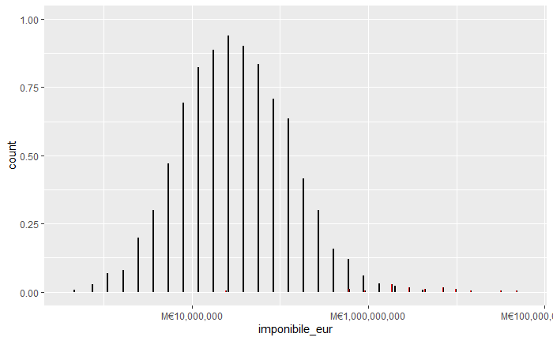

```r
## TODO : PUNTO IN PIU' FATTO A LEZIONE

max_regione <- redditi %>% group_by(Regione) %>%
  filter(imponibile_eur == max(imponibile_eur)) %>%
            select(Regione,Comune,imponibile_eur)

redditi %>%
  ggplot(aes(x=imponibile_eur))+
  geom_dotplot(dotsize = 0.02)+
  geom_dotplot(dotsize = 0.1,color="red",
              data=max_regione)+
  scale_x_log10(labels=label_dollar(prefix="M€"))
```

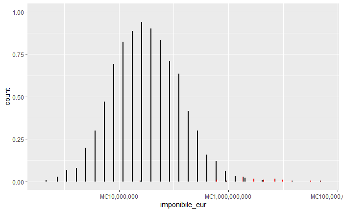

```r
redditi %>%
  ggplot(aes(x=imponibile_eur))+
  geom_dotplot(dotsize = 0.02)+
  geom_dotplot(dotsize = 0.1,color="red",
      data=function(.d){
        .d %>% group_by(Regione) %>%
          filter(imponibile_eur == max(imponibile_eur))
      })+
      scale_x_log10(labels=label_dollar(prefix="M€"))
```

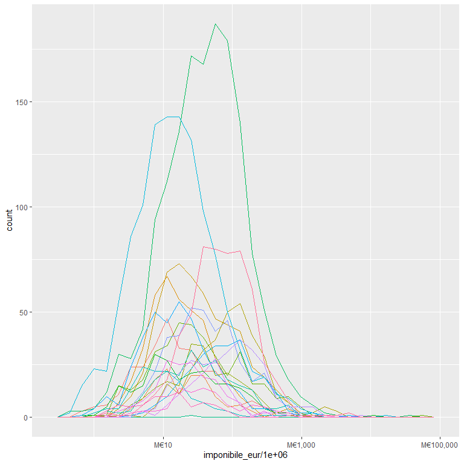

```r
## TODO : PUNTO IN PIU' FATTO A LEZIONE

ggplot(redditi,aes(x=imponibile_eur/1e6,color=Regione))+
  geom_freqpoly()+
  scale_color_discrete(guide="none")+
  scale_x_log10(labels=label_dollar(prefix="M€"))
```

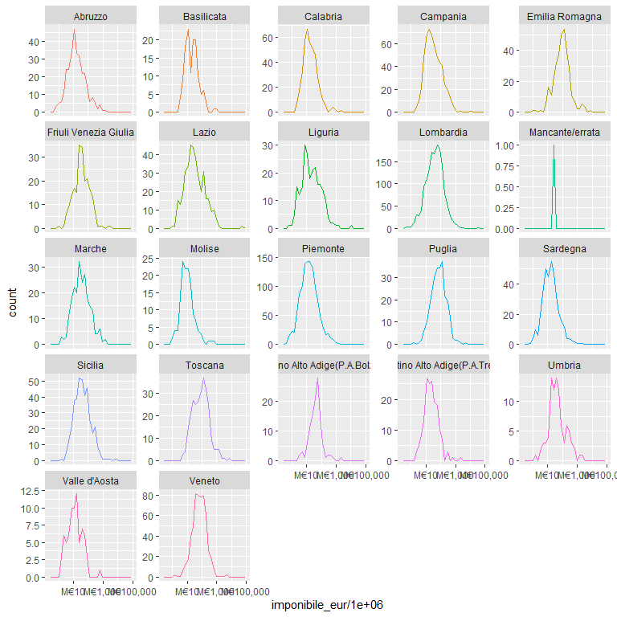

```r
ggplot(redditi,aes(x=imponibile_eur/1e6,color=Regione))+
  geom_freqpoly()+
  scale_color_discrete(guide="none")+
  facet_wrap(Regione~.,scale="free_y")+         # scale mi da che ogni grafico ha la propria asse y, quindi ogni grafico ha la scala che finisce al suo picco
  scale_x_log10(labels=label_dollar(prefix="M€"))
```

Conviene, per avere un’informazione più interessante, considerare il reddito medio pro-capite. Come è distribuito il reddito medio pro capite?

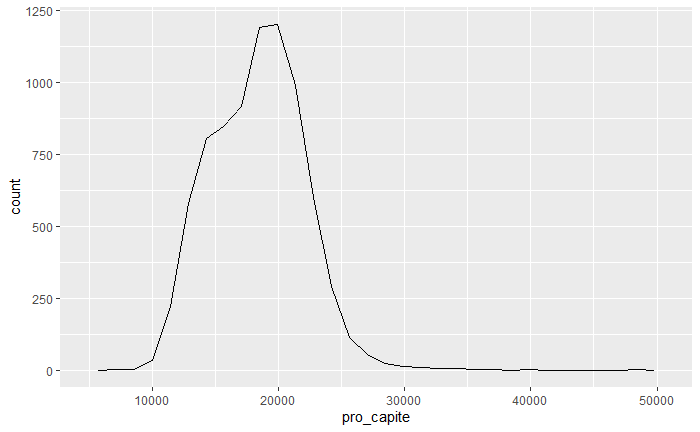

```r
### TODO : aggiungere una colonna con il reddito medio pro-capite e mostrare la distribuzione

redditi %<>% mutate(pro_capite = imponibile_eur / imponibile_n)

ggplot(redditi, aes(x=pro_capite))+geom_freqpoly()
```

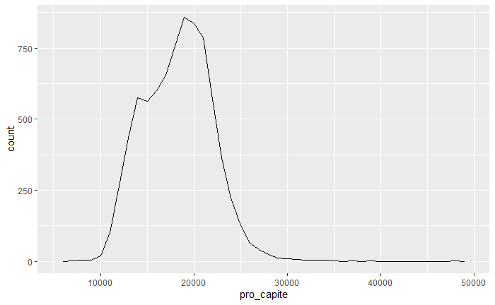

```r
ggplot(redditi, aes(x=pro_capite))+geom_freqpoly(binwidth=1000) # fa la media per comune, e poi mette plotta la distribuzione delle medie             L> 1000 euro => più dettagliato
```

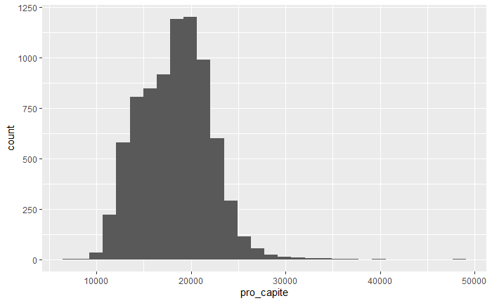

```r
ggplot(redditi, aes(x=pro_capite))+geom_histogram()
```

Quali sono i comuni con il più alto reddito pro-capite per ciascune regione?

```r
## TODO: trovare i comuni col maggior reddito imponibile pro-capite per regione (mostrare solo regione, nome comune e reddito-pro capite medio)

redditi <- redditi %>% filter(Regione!="Mancante/errata") # manca il nome di una regione

redditi %>% group_by(Regione) %>%
            filter(pro_capite == max(pro_capite)) %>%
            arrange(-pro_capite) %>%                      # ordina le righe di un frame di dati in base ai valori delle colonne selezionate in ordine descrescente, perché "-"
            select(Regione,Comune,pro_capite)
```

| Regione | Comune | pro_capite |
| --- | --- | --- |
| Lombardia | BASIGLIO | 48463.35 |
| Liguria | PIEVE LIGURE | 35277.84 |
| Piemonte | PINO TORINESE | 34526.75 |
| Marche | GABICCE MARE | 32636.11 |
| Toscana | LAJATICO | 30038.82 |
| Abruzzo | CUGNOLI | 29974.74 |
| Valle d'Aosta | GRESSONEY-LA-TRINITE' | 28961.88 |
| Trentino Alto Adige(P.A.Bolzano) | FALZES .PFALZEN. | 27922.98 |
| Emilia Romagna | SAN LAZZARO DI SAVENA | 27792.58 |
| Friuli Venezia Giulia | MORUZZO | 27575.96 |

[output cut: 11 more lines]

```r
NA
NA
```

Quali sono i redditi medi pro-capite per regione?

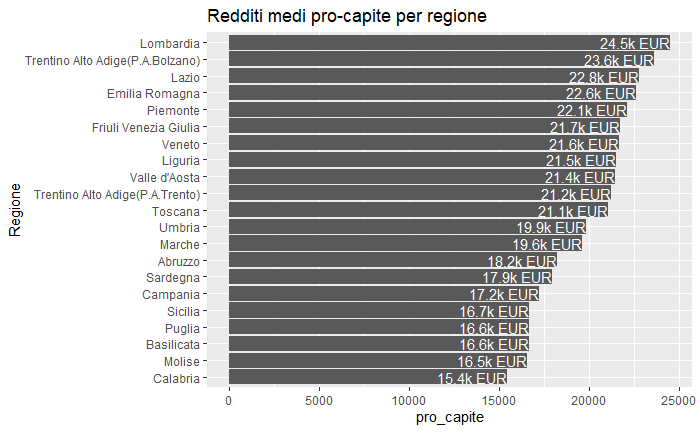

```r
## TODO : mostrare i redditi medi pro-capite per regione con un diagramma

redditi %>% group_by(Regione) %>%
  summarize(pro_capite = sum(imponibile_eur) / sum(imponibile_n) ) %>%
  arrange(pro_capite) %>%                     # ordina
  mutate(Regione = as_factor(Regione)) %>%    # prende le regioni e le trasform in fattori e i livelli sono quelli incontrati nell'ordine del data frame => ordino in base pro_capite
  # se a avessi usato as.factor mantiene l'ordine alfabetico e as_factor quello che trova nel data frame
ggplot(aes(y=Regione,x=pro_capite))+
  geom_col() +
  ggtitle("Redditi medi pro-capite per regione")+
  geom_text(aes(label=paste0(round(pro_capite/1000,1),"k EUR")),hjust=1,color="white")  # metto un testo pro_capite/mille, seguito da k EUR, allineato a DX, in bianco
```

Le colonne da 35 a 50 riportano una suddivisione per livello di reddito complessivo. Considerando solo le frequenze (non gli ammontare) si creai una versione del data frame che riporti le frequenze per ogni intervallo di redditi. Questo nuovo data frame può essere utilizzato per riportare a livello nazionale le distribuzioni tra i vari intervalli.

Suggerimento: conviene selezionare solo le colonne utili e poi fare un `pivot_longer`, prestare attenzione ai nomi degli intervalli (togliere i pezzi inutili con `str_remove()`) e all’ordinamento degli intervalli (che non deve essere alfabetico) utilizzando un fattore.

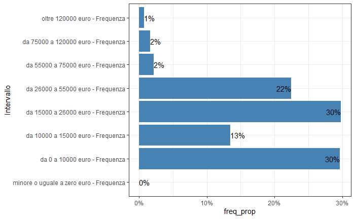

```r
## TODO : creare dataset con colonna corrispondente agli intervalli di reddito e una con la relativa frequenza,
## TODO : visualizzare le frequenze degli intervalli aggregate a livello nazionale

redditi_distrib <- redditi %>% select(-(1:3),-(7:34),-51,-ends_with("- Ammontare in euro")) %>% # NON selezionare le colonne da 1 a 3, 51 e quelle che finisco con "- Ammontare in euro"
            pivot_longer(starts_with("Reddito complessivo"),    # prendi quelli che cominciano così
                         names_to = "Intervallo",               # metti (i nomi delle colonne che cominciano con Redd...) in una colonna di nome "Intervallo"
                         values_to="Frequenza") %>%             # metti in Frequenza il valore della righa e colonna
            mutate(Intervallo = str_remove(Intervallo," - Frequenza|Reddito complessivo ")) %>% # da "Reddito complessivo minore o uguale a zero euro - Frequenza" diventa "minore o uguale a zero euro - Frequenza"
            mutate(Intervallo = as_factor(Intervallo))

redditi_distrib %>% group_by(Intervallo) %>% summarize(Frequenza=sum(Frequenza,na.rm=TRUE)) %>%
                    mutate(freq_prop=Frequenza/sum(Frequenza)) %>%
ggplot(aes(y=Intervallo,x=freq_prop))+
  geom_col(fill="steelblue")+
  scale_x_continuous(labels=scales::label_percent())+
  geom_text(aes(label=scales::percent(freq_prop,accuracy=1)),hjust="inward")+
  theme_bw()
```

Mostrare le frequenze dei diversi intervalli per ciascuna regione (facet).

Suggerimento: attenzione a valori speciali della colonna Regione, si consiglia di accorciare i nomi degli intervalli

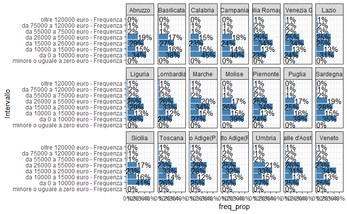

```r
## TODO : visualizzare le frequenze degli intervalli aggregate a livello nazionale

redditi_distrib %>% filter(Regione!="Mancante/errata") %>%
  group_by(Regione,Intervallo) %>%
  summarize(Frequenza=sum(Frequenza,na.rm=TRUE),.groups="drop_last") %>%
  mutate(freq_prop=Frequenza/sum(Frequenza)) %>%
ggplot(aes(y=Intervallo,x=freq_prop))+
  geom_col(fill="steelblue")+
  scale_x_continuous(labels=scales::label_percent(accuracy=1))+
  geom_text(aes(label=scales::percent(freq_prop,accuracy=1)),hjust="inward")+
  facet_wrap(Regione~.,ncol=7)+
  theme_bw()
```

EXTRA (non nel lab originale)

[figure not shown]

```r
redditi %>% group_by(Regione) %>%
            filter(pro_capite == max(pro_capite) |
                     pro_capite == min(pro_capite) |
                     contribuenti == max(contribuenti)) %>%
            mutate(capoluogo = contribuenti == max(contribuenti)) %>%
            mutate(is_max = pro_capite == max(pro_capite)) %>%
ggplot(aes(x=pro_capite,y=Regione, color=capoluogo, shape=capoluogo)) +
  geom_line(aes(group=Regione),color="grey50")+
  geom_point()+
  scale_color_discrete(guide="none")+scale_shape(guide="none")+
    geom_text(aes(label=Comune),vjust="bottom",nudge_y=0.3,size=2,color="gray20",
                  data=function(.d).d %>% filter(capoluogo))+
    geom_text(aes(label=Comune),hjust="left",nudge_x=1e3,size=2,color="gray20",
                  data=function(.d).d %>% filter(!capoluogo,is_max))+
    geom_text(aes(label=Comune),hjust="right",nudge_x=-1e3,size=2,color="gray20",
                  data=function(.d).d %>% filter(!capoluogo,!is_max))+
  scale_x_continuous(labels=scales::label_dollar(prefix="€"),
                     expand=expansion(add=c(9000,5000)))+
  ggtitle("Confronto capoluoghi e comuni più ricchi per regione","Reddito medio imponibile pro-capite anno 2020")+
  theme_bw()+theme(panel.grid.major.y = element_blank())
```